# Análisis del mercado inmobiliario en Cali

Alvaro Pérez Niño

Agosto de 2023

Introducción Objetivos Métodos Resultados Discusiones y conclusiones Anexos Autor

# Introducción

La aplicación de la ciencia de datos en el sector de bienes raíces, ha surgido como un dinamizador de cambio, revolucionando la forma en que se comprenden, pronostican y gestionan las dinámicas propias de este sector. Los grandes volúmenes de información, los avances tecnológicos y las técnicas analíticas implementadas ha permitido a los actores del mercado de bienes raíces abordar desafíos cruciales con un enfoque más preciso y fundamentado. Desde la valoración de propiedades hasta la identificación de tendencias en la demanda y el diseño de estrategias de inversión, la ciencia de datos emerge como un aliado estratégico, empoderando a profesionales y empresas para tomar decisiones informadas en un mercado caracterizado por su volatilidad y complejidad.

La empresa **B&C (Bines y Casas)** es una agencia de bienes raíces que opera en la ciudad de Cali, Colombia. La empresa fue fundada por Sandra Milena hace 10 años y actualmente cuenta con ocho agentes de bienes raíces. El mercado de bienes raíces en Cali ha crecido significativamente en los últimos años, impulsado por el crecimiento de la población, la inversión extranjera directa y el desarrollo de nuevos proyectos inmobiliarios. En 2021, las ventas del sector en Cali llegaron a $6700 millones y en 2022 a $6100 mil millones. Se espera que este sector continue creciendo durante los próximos años, permitiendo un desarrollo dinámico en la economía regional.

Regresar ...

# Objetivos

### **General**

Desarrollar un informe de análisis descriptivo del mercado inmobiliario en la ciudad de Cali, Colombia

### **Específicos**

- Identificar las principales preferencias socioeconómicas de los ciudadanos para adquirir una vivienda en la ciudad de Cali, Colombia.
- Caracterizar las principales preferencias socioeconómicas de los ciudadanos para adquirir una vivienda en la ciudad de Cali, Colombia.
- Diseñar un análisis descriptivo en relación a la caracterización de las preferencias de los ciudadanos en Cali para adquirir una vivienda.

Regresar ...

# Métodos

Este informe ha sido elaborado siguiendo las Etapas en la Aplicación de Ciencia de Datos: Importación, Organización, Transformación, Visualización, Modelado y Comunicación. A partir de este marco, hemos estructurado el proceso en las siguientes fases:

- **Fase 01:** Procesamiento de datos
- **Fase 02:** Modelamiento de datos
- **Fase 03:** Visualización y comunicación de datos

Señor@ usuario **dar clic** en cada una de las secciones de la parte inferior.

Fase No.01: Procesar

Fase No.02: Modelar

Fase No.03: Visualizar

### 3.1 Fase 01: Procesamiento de datos

Durante esta fase, se llevaron a cabo diversas tareas orientadas a preparar el entorno de trabajo, cargar las librerías necesarias para el proyecto, consolidar los datos provenientes de diversas fuentes, descartar variables que carecían de relevancia o presentaban redundancias, realizar un análisis estadístico detallado para lograr una comprensión sustantiva de los datos y, además, llevar a cabo una depuración minuciosa con el fin de limpiar los datos en función de las necesidades específicas.

**3.1.1 Adecuación del espacio de trabajo**

```r
rm(list = ls())
```

**3.1.2 Cargue de librerías a utilizar**

```r
library(gdata)
    library(dplyr)
    library(ggplot2)
    library(leaflet)
    library(knitr)
    library(reshape2)
```

**3.1.3 Cargue de los datos**

```r
Datos <- read.csv(file = file.choose(), header = TRUE, sep = ",")
```

**3.1.4 Información de las variables**

```r
str(Datos)
```

```
## 'data.frame':    8330 obs. of  13 variables:
    ##  $ id       : int  8312 8311 8307 8296 8297 8298 8299 8300 8286 8287 ...
    ##  $ zona     : chr  "Zona Oeste" "Zona Oeste" "Zona Oeste" "Zona Sur" ...
    ##  $ piso     : int  4 1 NA 2 NA NA 2 NA NA 2 ...
    ##  $ estrato  : int  6 6 5 3 5 5 6 5 5 5 ...
    ##  $ preciom  : int  1300 480 1200 220 330 1350 305 480 275 285 ...
    ##  $ areaconst: num  318 300 800 150 112 390 125 280 74 120 ...
    ##  $ parquea  : int  2 1 4 1 2 8 2 4 1 2 ...
    ##  $ banios   : int  4 4 7 2 4 10 3 4 2 4 ...
    ##  $ habitac  : int  2 4 5 4 3 10 3 4 3 3 ...
    ##  $ tipo     : chr  "Apartamento" "Casa" "Casa" "Casa" ...
    ##  $ barrio   : chr  "arboleda" "normandía" "miraflores" "el guabal" ...
    ##  $ longitud : num  -76576 -76571 -76568 -76565 -76565 ...
    ##  $ latitud  : num  3454 3454 3455 3417 3408 ...
```

**3.1.5 Descripción estadística inicial de las variables**

```r
summary(Datos)
```

```
##        id           zona                piso           estrato
    ##  Min.   :   1   Length:8330        Min.   : 1.000   Min.   :3.000
    ##  1st Qu.:2082   Class :character   1st Qu.: 2.000   1st Qu.:4.000
    ##  Median :4164   Mode  :character   Median : 3.000   Median :5.000
    ##  Mean   :4164                      Mean   : 3.772   Mean   :4.634
    ##  3rd Qu.:6246                      3rd Qu.: 5.000   3rd Qu.:5.000
    ##  Max.   :8319                      Max.   :12.000   Max.   :6.000
    ##  NA's   :3                         NA's   :2641     NA's   :3
    ##     preciom         areaconst       parquea           banios
    ##  Min.   :  58.0   Min.   :  30   Min.   : 1.000   Min.   : 0.000
    ##  1st Qu.: 220.0   1st Qu.:  80   1st Qu.: 1.000   1st Qu.: 2.000
    ##  Median : 330.0   Median : 123   Median : 2.000   Median : 3.000
    ##  Mean   : 434.2   Mean   : 175   Mean   : 1.836   Mean   : 3.112
    ##  3rd Qu.: 540.0   3rd Qu.: 229   3rd Qu.: 2.000   3rd Qu.: 4.000
    ##  Max.   :1999.0   Max.   :1745   Max.   :10.000   Max.   :10.000
    ##  NA's   :2        NA's   :3      NA's   :1606     NA's   :3
    ##     habitac           tipo              barrio             longitud
    ##  Min.   : 0.000   Length:8330        Length:8330        Min.   :-76576.00
    ##  1st Qu.: 3.000   Class :character   Class :character   1st Qu.:-76506.00
    ##  Median : 3.000   Mode  :character   Mode  :character   Median :   -76.54
    ##  Mean   : 3.605                                         Mean   :-21845.13
    ##  3rd Qu.: 4.000                                         3rd Qu.:   -76.52
    ##  Max.   :10.000                                         Max.   :   -76.46
    ##  NA's   :3                                              NA's   :3
    ##     latitud
    ##  Min.   :   3.333
    ##  1st Qu.:   3.390
    ##  Median :   3.450
    ##  Mean   : 970.370
    ##  3rd Qu.:3367.000
    ##  Max.   :3497.000
    ##  NA's   :3
```

**3.1.6 Eliminar variables irrelevantes y redundantes**

Basándonos en el análisis estadístico preliminar de las variables, se ha llegado a la conclusión de que la variable “id” se considera irrelevante para el estudio en el ámbito inmobiliario.

```r
Datos=select(Datos, -id)
```

**3.1.7 Descripción estadística de los datos**

**3.1.7.1 Variables Cuantitativas**

- **Variable pisos:** valor numérico entero, relacionado con la ubicación horizontal de la vivienda Ej: 3

```r
summary(Datos$piso)
```

```
##    Min. 1st Qu.  Median    Mean 3rd Qu.    Max.    NA's
    ##   1.000   2.000   3.000   3.772   5.000  12.000    2641
```

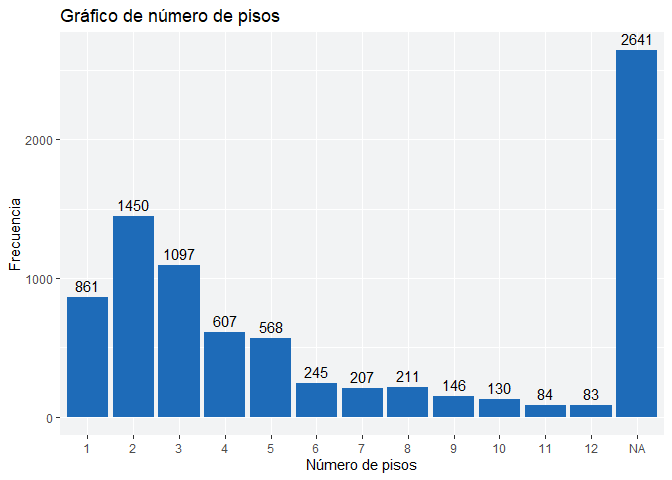

```r
ggplot(Datos, aes(x = factor(piso))) + geom_bar(fill = "#1E6BB8") +
      geom_text(stat = "count", aes(label = after_stat(count)), vjust = -0.5) +
      labs(x = "Número de pisos", y = "Frecuencia", title = "Gráfico de número de pisos") +
      theme(panel.background = element_rect(fill = "#F2F3F4"))
```

- **Variable estrato:** valor numérico entero, relacionado con el estrato socioeconómicas de la ubicacion de las viviendas Ej: 4

```r
summary(Datos$estrato)
```

```
##    Min. 1st Qu.  Median    Mean 3rd Qu.    Max.    NA's
    ##   3.000   4.000   5.000   4.634   5.000   6.000       3
```

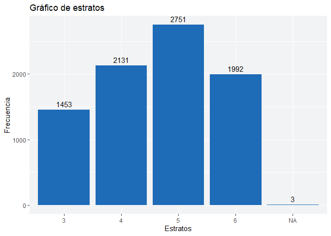

```r
ggplot(Datos, aes(x = factor(estrato))) + geom_bar(fill = "#1E6BB8") +
      geom_text(stat = "count", aes(label = after_stat(count)), vjust = -0.5) +
      labs(x = "Estratos", y = "Frecuencia", title = "Gráfico de estratos") +
      theme(panel.background = element_rect(fill = "#F2F3F4"))
```

- **Variable preciom:** valor numérico entero, relacionado con el costo de aquisicion de la vivienda en millones de pesos COP Ej: 300

```r
summary(Datos$preciom)
```

```
##    Min. 1st Qu.  Median    Mean 3rd Qu.    Max.    NA's
    ##    58.0   220.0   330.0   434.2   540.0  1999.0       2
```

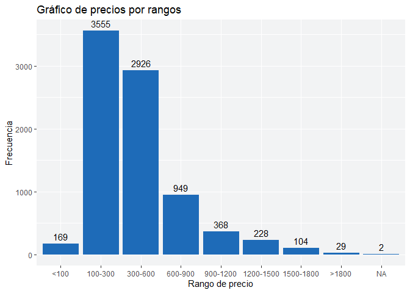

```r
Datos$rango_precio <- cut(Datos$preciom,
                              breaks = c(-Inf, 100, 300, 600, 900, 1200, 1500, 1800,
                                         Inf),
                              labels = c("<100", "100-300", "300-600", "600-900",
                                         "900-1200", "1200-1500", "1500-1800", ">1800"))

    ggplot(Datos, aes(x = rango_precio)) +
      geom_bar(fill = "#1E6BB8") +
      geom_text(stat = "count", aes(label = after_stat(count)), vjust = -0.5) +
      labs(x = "Rango de precio", y = "Frecuencia", title = "Gráfico de precios por rangos") +
      theme(panel.background = element_rect(fill = "#F2F3F4"))
```

- **Variable areaconst:** valor numérico decimal, relacionado con el area construida de la vivienda Ej: 45.6

```r
summary(Datos$areaconst)
```

```
##    Min. 1st Qu.  Median    Mean 3rd Qu.    Max.    NA's
    ##      30      80     123     175     229    1745       3
```

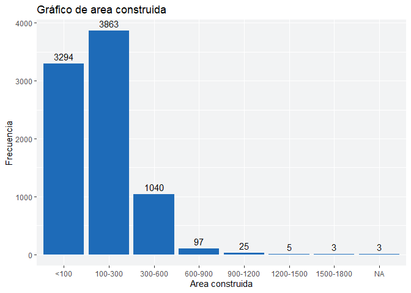

```r
Datos$rango_area <- cut(Datos$areaconst,
                              breaks = c(-Inf, 100, 300, 600, 900, 1200, 1500, 1800,
                                         Inf),
                              labels = c("<100", "100-300", "300-600", "600-900",
                                         "900-1200", "1200-1500", "1500-1800", ">1800"))

    ggplot(Datos, aes(x = rango_area)) +
      geom_bar(fill = "#1E6BB8") +
      geom_text(stat = "count", aes(label = after_stat(count)), vjust = -0.5) +
      labs(x = "Area construida", y = "Frecuencia", title = "Gráfico de area construida") +
      theme(panel.background = element_rect(fill = "#F2F3F4"))
```

- **Variable parquea:** valor numérico entero, relacionado con el numero de espacios disponibles para parqueadero de la vivienda Ej: 4

```r
summary(Datos$parquea)
```

```
##    Min. 1st Qu.  Median    Mean 3rd Qu.    Max.    NA's
    ##   1.000   1.000   2.000   1.836   2.000  10.000    1606
```

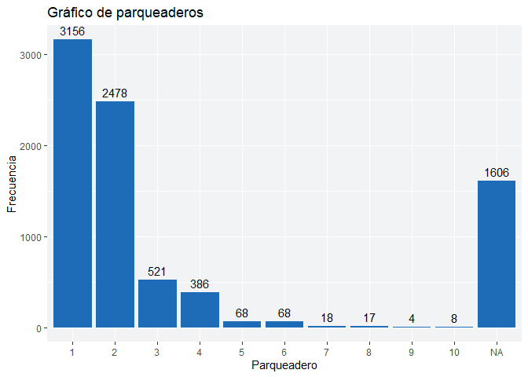

```r
ggplot(Datos, aes(x = factor(parquea))) + geom_bar(fill = "#1E6BB8") +
      geom_text(stat = "count", aes(label = after_stat(count)), vjust = -0.5) +
      labs(x = "Parqueadero", y = "Frecuencia", title = "Gráfico de parqueaderos") +
      theme(panel.background = element_rect(fill = "#F2F3F4"))
```

- **Variable banios:** valor numérico entero, relacionado con el numero de baterias sanitarias que tiene la vivienda Ej: 3

```r
summary(Datos$banios)
```

```
##    Min. 1st Qu.  Median    Mean 3rd Qu.    Max.    NA's
    ##   0.000   2.000   3.000   3.112   4.000  10.000       3
```

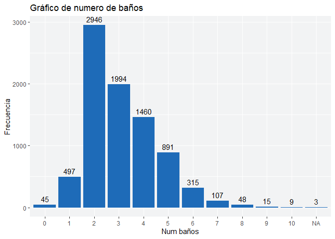

```r
ggplot(Datos, aes(x = factor(banios))) + geom_bar(fill = "#1E6BB8") +
      geom_text(stat = "count", aes(label = after_stat(count)), vjust = -0.5) +
      labs(x = "Num baños", y = "Frecuencia", title = "Gráfico de numero de baños") +
      theme(panel.background = element_rect(fill = "#F2F3F4"))
```

- **Variable habitac:** valor numérico entero, relacionado con el numero de habitaciones que tiene la vivienda Ej: 3

```r
summary(Datos$habitac)
```

```
##    Min. 1st Qu.  Median    Mean 3rd Qu.    Max.    NA's
    ##   0.000   3.000   3.000   3.605   4.000  10.000       3
```

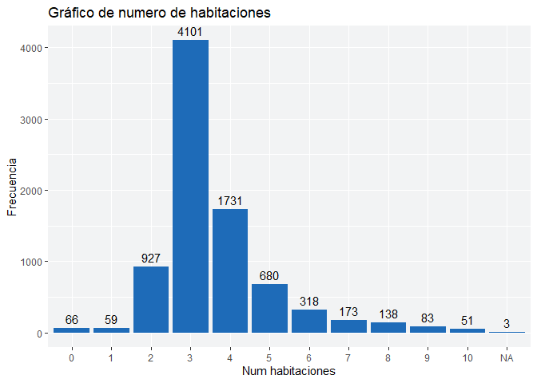

```r
ggplot(Datos, aes(x = factor(habitac))) + geom_bar(fill = "#1E6BB8") +
      geom_text(stat = "count", aes(label = after_stat(count)), vjust = -0.5) +
      labs(x = "Num habitaciones", y = "Frecuencia", title = "Gráfico de numero de habitaciones") +
      theme(panel.background = element_rect(fill = "#F2F3F4"))
```

**3.1.7.2 Variables Cualitativas**

- **Variable zona:** valor categorico, relacionado con la ubicación de la vivienda segun la zona (Norte, Oriente, Oeste, Centro y Sur)

```r
summary(Datos$zona)
```

```
##    Length     Class      Mode
    ##      8330 character character
```

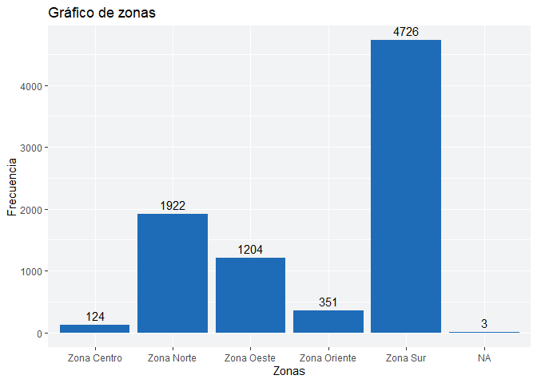

```r
ggplot(Datos, aes(x = zona, fill = zona)) + geom_bar(fill = "#1E6BB8") +
      geom_text(stat = 'count', aes(label = after_stat(count)), vjust = -0.5) +
      labs(x = "Zonas", y = "Frecuencia", title = "Gráfico de zonas") +
      theme(panel.background = element_rect(fill = "#F2F3F4"))
```

- **Variable tipo:** valor categorico, relacionado con el tipo de vivienda (Apartamento o Casa)

```r
summary(Datos$tipo)
```

```
##    Length     Class      Mode
    ##      8330 character character
```

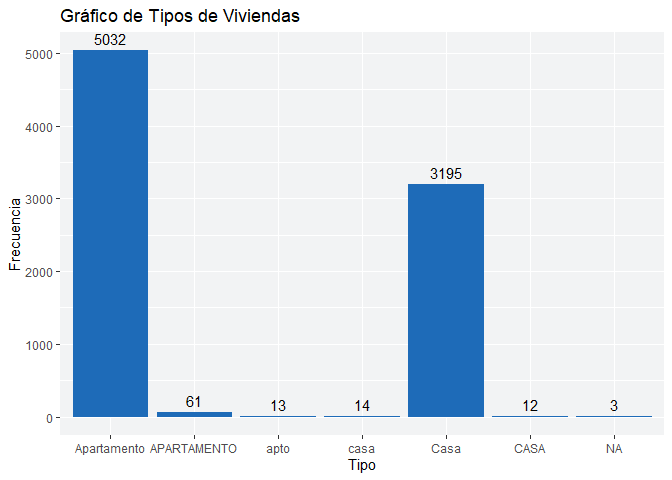

```r
ggplot(Datos, aes(x = tipo, fill = tipo)) + geom_bar(fill = "#1E6BB8") +
      geom_text(stat = 'count', aes(label = after_stat(count)), vjust = -0.5) +
      labs(x = "Tipo", y = "Frecuencia", title = "Gráfico de Tipos de Viviendas") +
      theme(panel.background = element_rect(fill = "#F2F3F4"))
```

- **Variables (barrio, latitud y longitud):** valores categóricos y numéricos, relacionados con la ubicación geográfica espacial de cada una de las viviendas. Las viviendas de la zona norte estara representadas en color naranja, las viviendas de la zona oriente de color morado, las viviendas de la zona centro de color azul, las viviendas de la zona oeste de color verde y las viviendas de la zona sur en color amarillo.

```
## Warning in validateCoords(lng, lat, funcName): Data contains 3 rows with either
    ## missing or invalid lat/lon values and will be ignored
```

[interactive chart not shown]

**3.1.8 Limpieza de datos**

**3.1.8.1 Eliminación de registros completamente vacios (NA)**

En el conjunto de datos, se identificaron (03) registros que carecían por completo de información. Ante esta situación, se optó por eliminar dichos registros del conjunto de datos.

```r
Datos <- Datos[complete.cases(Datos$zona), ]
```

**3.1.8.2 Imputación de variables cuantitativas**

Se observaron valores faltantes (NA) en las variables piso, parquea, banios y habitac. Estos valores incompletos se abordaron mediante la imputación de la media correspondiente. Es esencial considerar que la variable piso exhibe 2641 datos faltantes, mientras que la variable parquea presenta 1606 datos faltantes. Estas dos variables son las que más carencias presentan, lo cual podría introducir un sesgo significativo en el estudio.

- **Variable número de pisos**

```r
media_piso <- mean(Datos$piso[Datos$piso != 0 & !is.na(Datos$piso)], na.rm = TRUE)
    media_piso <- round(media_piso)
    Datos <- Datos %>%
      mutate(piso = ifelse(piso == 0 | is.na(piso), media_piso, piso))
```

- **Variable parqueadero**

```r
media_parquea <- mean(Datos$parquea[Datos$parquea != 0 & !is.na(Datos$parquea)], na.rm = TRUE)
    media_parquea <- round(media_parquea)
    Datos <- Datos %>%
      mutate(parquea = ifelse(parquea == 0 | is.na(parquea), media_parquea, parquea))
```

- **Variable número de baños**

```r
media_banios <- mean(Datos$banios[Datos$banios != 0 & !is.na(Datos$banios)], na.rm = TRUE)
    media_banios <- round(media_banios)
    Datos <- Datos %>%
      mutate(banios = ifelse(banios == 0 | is.na(banios), media_banios, banios))
```

- **Variable número de habitaciones**

```r
media_habitac <- mean(Datos$habitac[Datos$habitac != 0 & !is.na(Datos$habitac)], na.rm = TRUE)
    media_habitac <- round(media_habitac)
    Datos <- Datos %>%
      mutate(habitac = ifelse(habitac == 0 | is.na(habitac), media_habitac, habitac))
```

**3.1.8.3 Imputación de variables cualitativas**

Los datos han sido procesados para estandarizar la variable “tipo” y agrupar las categorías relacionadas. Las entradas que originalmente tenían etiquetas como “apto” o “APARTAMENTO” han sido reasignadas a “Apartamento”. De manera similar, las categorías “CASA” o “casa” han sido unificadas bajo la etiqueta “Casa”. Este proceso busca homogeneizar las categorías y mejorar la consistencia en el conjunto de datos.

- **Variable tipo de vivienda**

```r
Datos <- Datos %>%
      mutate(tipo = ifelse(tipo == "apto" | tipo == "APARTAMENTO", "Apartamento", tipo))

    Datos <- Datos %>%
      mutate(tipo = ifelse(tipo == "CASA" | tipo == "casa", "Casa", tipo))
```

### 3.2 Fase 02: Modelamiento de datos

Durante esta fase, se procede a modelar las variables a través de un análisis de cruces entre aquellas que resultan representativas y que ejercen influencia en los usuarios de la inmobiliaria al momento de adquirir una vivienda. Esto abarca factores como la consideración económica y las distintas características del inmueble que desempeñan un papel crucial en el proceso de toma de decisiones.

**3.2.1 Modelamiento de datos por el Factor Economico**

- **Modelamiento precio vs tipo de vivienda**

```r
tabla_tipo <- Datos %>%
      group_by(tipo) %>%
      summarise(
        suma_precio = sum(preciom, na.rm = TRUE),
        promedio_precio = round(mean(preciom, na.rm = TRUE)),
        Count = n()
      ) %>%
      mutate(
        suma_precio = format(suma_precio, big.mark = ",", scientific = FALSE),
        promedio_precio = format(promedio_precio, big.mark = ",", scientific = FALSE),
        Count = format(Count, big.mark = ",", scientific = FALSE)
      )
    kable(tabla_tipo, format = "markdown")
```

| tipo | suma_precio | promedio_precio | Count |
| --- | --- | --- | --- |
| Apartamento | 1,877,086 | 368 | 5,106 |
| Casa | 1,738,940 | 540 | 3,221 |

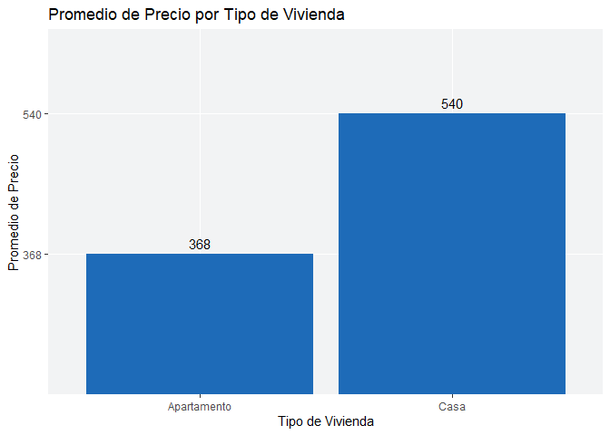

```r
ggplot(tabla_tipo, aes(x = tipo, y = promedio_precio, fill = tipo)) +
      geom_bar(stat = "identity", fill = "#1E6BB8") +
      geom_text(aes(label = promedio_precio), vjust = -0.5) +
      labs(x = "Tipo de Vivienda", y = "Promedio de Precio",
           title = "Promedio de Precio por Tipo de Vivienda") +
      theme(legend.position = "none",
            panel.background = element_rect(fill = "#F2F3F4"))
```

- **Modelamiento precio vs zonas**

```r
tabla_zona <- Datos %>%
      group_by(zona) %>%
      summarise(
        suma_precio = sum(preciom, na.rm = TRUE),
        promedio_precio = round(mean(preciom, na.rm = TRUE)),
        Count = n()
      ) %>%
      mutate(
        suma_precio = format(suma_precio, big.mark = ",", scientific = FALSE),
        promedio_precio = format(promedio_precio, big.mark = ",", scientific = FALSE),
        Count = format(Count, big.mark = ",", scientific = FALSE)
      )
    kable(tabla_zona, format = "markdown")
```

| zona | suma_precio | promedio_precio | Count |
| --- | --- | --- | --- |
| Zona Centro | 38,402 | 310 | 124 |
| Zona Norte | 664,548 | 346 | 1,922 |
| Zona Oeste | 817,136 | 679 | 1,204 |
| Zona Oriente | 80,214 | 229 | 351 |
| Zona Sur | 2,015,726 | 427 | 4,726 |

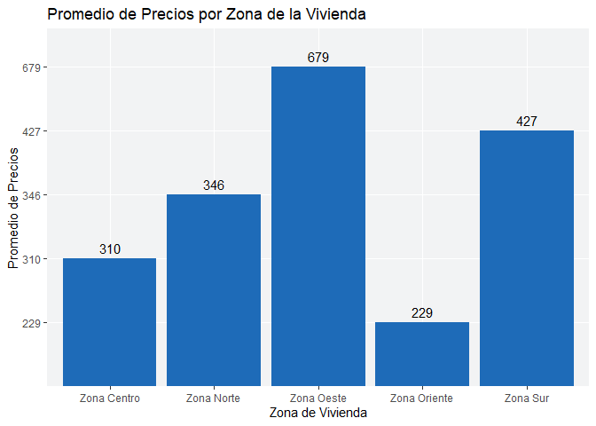

```r
ggplot(tabla_zona, aes(x = zona, y = promedio_precio, fill = zona)) +
      geom_bar(stat = "identity", fill = "#1E6BB8") +
      geom_text(aes(label = promedio_precio), vjust = -0.5) +
      labs(x = "Zona de Vivienda", y = "Promedio de Precios",
           title = "Promedio de Precios por Zona de la Vivienda") +
      theme(legend.position = "none",
            panel.background = element_rect(fill = "#F2F3F4"))
```

- **Modelamiento precio vs estrato**

```r
tabla_estrato <- Datos %>%
      group_by(estrato) %>%
      summarise(
        suma_precio = sum(preciom, na.rm = TRUE),
        promedio_precio = round(mean(preciom, na.rm = TRUE)),
        Count = n()
      ) %>%
      mutate(
        suma_precio = format(suma_precio, big.mark = ",", scientific = FALSE),
        promedio_precio = format(promedio_precio, big.mark = ",", scientific = FALSE),
        Count = format(Count, big.mark = ",", scientific = FALSE)
      )
    kable(tabla_estrato, format = "markdown")
```

| estrato | suma_precio | promedio_precio | Count |
| --- | --- | --- | --- |
| 3 | 305,600 | 210 | 1,453 |
| 4 | 586,417 | 275 | 2,131 |
| 5 | 1,128,590 | 410 | 2,751 |
| 6 | 1,595,419 | 801 | 1,992 |

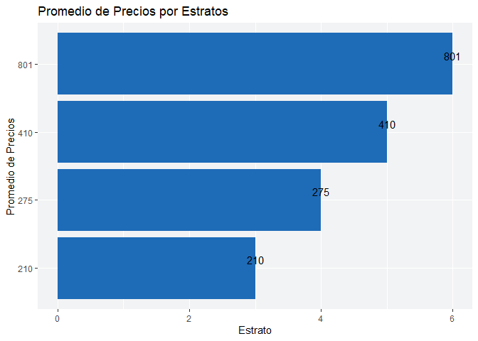

```r
ggplot(tabla_estrato, aes(x = estrato, y = promedio_precio, fill = estrato)) +
      geom_bar(stat = "identity", fill = "#1E6BB8") +
      geom_text(aes(label = promedio_precio), vjust = -0.5) +
      labs(x = "Estrato", y = "Promedio de Precios",
           title = "Promedio de Precios por Estratos") +
      theme(legend.position = "none",
            panel.background = element_rect(fill = "#F2F3F4"))
```

- **Modelamiento precio vs tamaño de vivienda**

```r
rangos <- c(0, 100, 300, 600, Inf)
    Datos$grupo_area <- cut(Datos$areaconst, breaks = rangos, labels =
                              c("0-100", "100-300", "300-600", ">600"), right = FALSE)
    tabla_tamanio <- Datos %>%
      group_by(grupo_area) %>%
      summarise(
        suma_precio = sum(preciom, na.rm = TRUE),
        promedio_precio = round(mean(preciom, na.rm = TRUE)),
        Count = n()
      ) %>%
      mutate(
        suma_precio = format(suma_precio, big.mark = ",", scientific = FALSE),
        promedio_precio = format(promedio_precio, big.mark = ",", scientific = FALSE),
        Count = format(Count, big.mark = ",", scientific = FALSE)
      )
    kable(tabla_tamanio, format = "markdown")
```

| grupo_area | suma_precio | promedio_precio | Count |
| --- | --- | --- | --- |
| 0-100 | 660,806 | 209 | 3,165 |
| 100-300 | 1,837,265 | 478 | 3,846 |
| 300-600 | 939,189 | 810 | 1,160 |
| >600 | 178,766 | 1,146 | 156 |

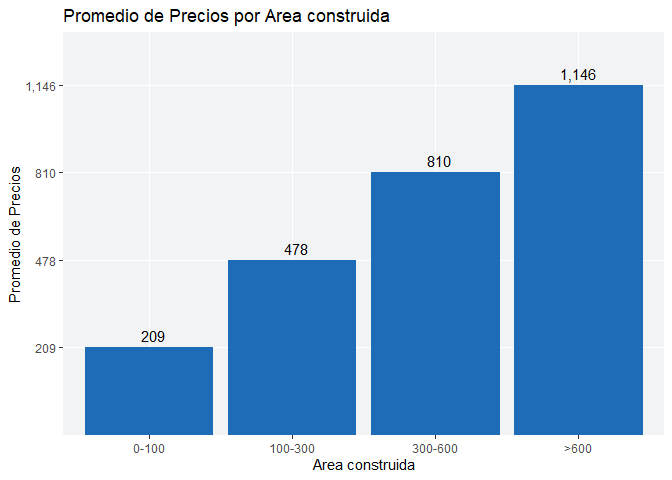

```r
ggplot(tabla_tamanio, aes(x = grupo_area, y = promedio_precio, fill = grupo_area)) +
      geom_bar(stat = "identity", fill = "#1E6BB8") +
      geom_text(aes(label = promedio_precio), vjust = -0.5) +
      labs(x = "Area construida", y = "Promedio de Precios",
           title = "Promedio de Precios por Area construida") +
      theme(legend.position = "none",
            panel.background = element_rect(fill = "#F2F3F4"))
```

**3.2.2 Modelamiento de datos por el Factor Caracteristicas de Vivienda**

- **Modelamiento tipo de vivienda vs zonas**

```r
tabla_tipozona <- Datos %>%
      group_by(zona) %>%
      summarise(
        apartamento = sum(tipo == "Apartamento", na.rm = TRUE),
        casa = sum(tipo == "Casa", na.rm = TRUE),
        sum = n()
      )
    total_apartamento <- sum(tabla_tipozona$apartamento, na.rm = TRUE)
    total_casa <- sum(tabla_tipozona$casa, na.rm = TRUE)
    tabla_tipozona <- tabla_tipozona %>%
      add_row(zona = "Total", apartamento = total_apartamento, casa = total_casa)

    kable(tabla_tipozona, format = "markdown")
```

| zona | apartamento | casa | sum |
| --- | --- | --- | --- |
| Zona Centro | 24 | 100 | 124 |
| Zona Norte | 1199 | 723 | 1922 |
| Zona Oeste | 1035 | 169 | 1204 |
| Zona Oriente | 62 | 289 | 351 |
| Zona Sur | 2786 | 1940 | 4726 |
| Total | 5106 | 3221 | NA |

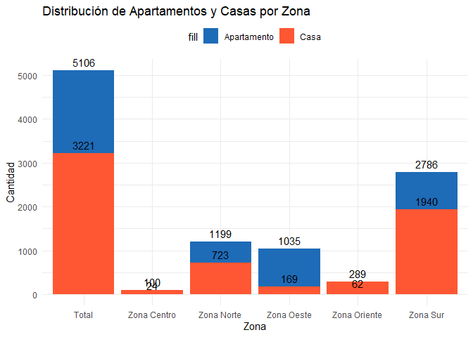

```r
ggplot(tabla_tipozona, aes(x = zona)) +
      geom_bar(aes(y = apartamento, fill = "Apartamento"), position = "dodge", stat = "identity") +
      geom_bar(aes(y = casa, fill = "Casa"), position = "dodge", stat = "identity") +
      geom_text(aes(y = apartamento, label = apartamento), position = position_dodge(width = 0.8),
                vjust = -0.5) +
      geom_text(aes(y = casa, label = casa), position = position_dodge(width = 0.8), vjust = -0.5) +
      scale_fill_manual(values = c(Apartamento = "#1E6BB8", Casa = "#FF5733")) +
      labs(x = "Zona", y = "Cantidad",
           title = "Distribución de Apartamentos y Casas por Zona") +
      theme_minimal() +
      theme(legend.position = "top")
```

- **Modelamiento tipo de vivienda vs estrato**

```r
tabla_tipoestrato <- Datos %>%
      group_by(estrato) %>%
      summarise(
        apartamento = sum(tipo == "Apartamento", na.rm = TRUE),
        casa = sum(tipo == "Casa", na.rm = TRUE),
        sum = n()
      )
    total_apartamento <- sum(tabla_tipoestrato$apartamento, na.rm = TRUE)
    total_casa <- sum(tabla_tipoestrato$casa, na.rm = TRUE)
    tabla_tipoestrato <- tabla_tipoestrato %>%
      add_row(estrato = -1, apartamento = total_apartamento, casa = total_casa)
    tabla_tipoestrato$estrato[tabla_tipoestrato$estrato == -1] <- "Total"

    kable(tabla_tipoestrato, format = "markdown")
```

| estrato | apartamento | casa | sum |
| --- | --- | --- | --- |
| 3 | 639 | 814 | 1453 |
| 4 | 1404 | 727 | 2131 |
| 5 | 1767 | 984 | 2751 |
| 6 | 1296 | 696 | 1992 |
| Total | 5106 | 3221 | NA |

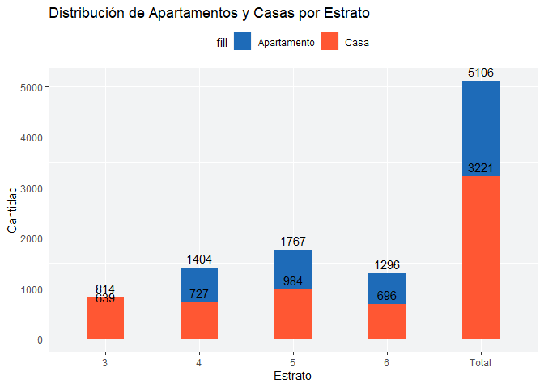

```r
ggplot(tabla_tipoestrato, aes(x = estrato)) +
      geom_bar(aes(y = apartamento, fill = "Apartamento"), position = "dodge", stat = "identity", width = 0.4) +
      geom_bar(aes(y = casa, fill = "Casa"), position = "dodge", stat = "identity", width = 0.4) +
      geom_text(aes(y = apartamento, label = apartamento), position = position_dodge(width = 0.4), vjust = -0.5, size = 4) +
      geom_text(aes(y = casa, label = casa), position = position_dodge(width = 0.4), vjust = -0.5, size = 4) +
      scale_fill_manual(values = c(Apartamento = "#1E6BB8", Casa = "#FF5733")) +
      labs(x = "Estrato", y = "Cantidad",
           title = "Distribución de Apartamentos y Casas por Estrato") +
      theme(legend.position = "top",
            panel.background = element_rect(fill = "#F2F3F4"))
```

### 3.3 Fase 03: Visualización del modelamiento de datos

**3.3.1 Visualizaciones de datos por el Factor Economico**

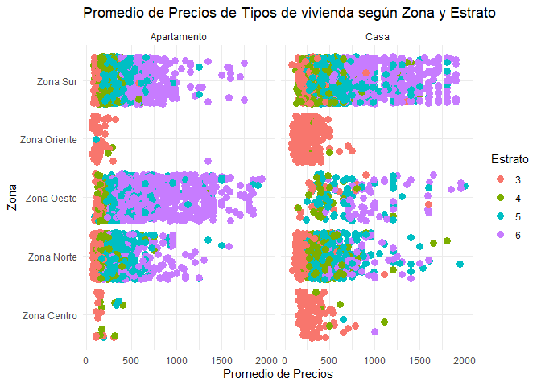

```r
ggplot(Datos, aes(x = preciom, y = zona, color = factor(estrato))) +
          geom_point(position = position_jitter(width = 0.2), size = 3) +
          facet_grid(. ~ tipo) +
          labs(x = "Promedio de Precios", y = "Zona",
               title = "Promedio de Precios de Tipos de vivienda según Zona y Estrato",
               color = "Estrato") +
          scale_color_discrete(name = "Estrato") +
          theme_minimal()
```

- **Tipo de vivienda según la zona, el estrato y el area construida de la vivienda**

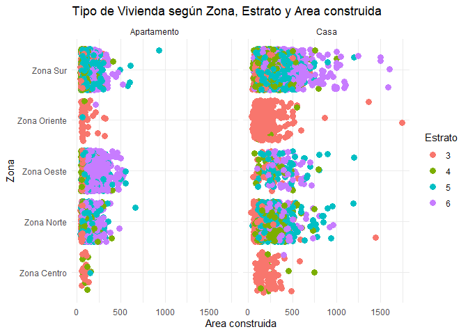

```r
ggplot(Datos, aes(x = areaconst, y = zona, color = factor(estrato))) +
          geom_point(position = position_jitter(width = 0.2), size = 3) +
          facet_grid(. ~ tipo) +
          labs(x = "Area construida", y = "Zona",
               title = "Tipo de Vivienda según Zona, Estrato y Area construida") +
          scale_color_discrete(name = "Estrato") +
          theme_minimal()
```

**3.3.2 Visualizaciones de datos por el Factor Caracteristicas de Vivienda**

- **Correlación de las características de la vivienda tipo “Casa”**

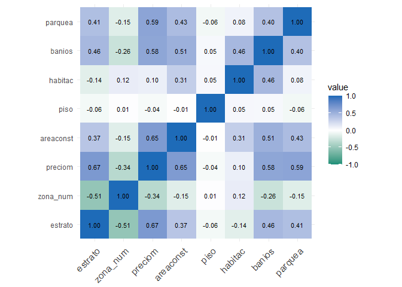

  ```r
  df_casa <- Datos[Datos$tipo == "Casa",]

          correlation_matrix <- cor(df_casa[,c("estrato", "zona_num", "preciom", "areaconst", "piso", "habitac", "banios", "parquea")])

          correlation_df <- reshape2::melt(correlation_matrix)

          ggplot(data = correlation_df, aes(x=Var1, y=Var2, fill=value)) +
            geom_tile() +
            geom_text(aes(label=sprintf("%.2f", value)), color="black", size=3) +
            scale_fill_gradient2(low = "#148F77", high = "#1E6BB8", mid = "white",
                                 midpoint = 0, limit = c(-1,1), space = "Lab") +
            theme_minimal() +
            theme(axis.text.x = element_text(angle = 45, vjust = 1,
                                             size = 12, hjust = 1),
                  axis.title = element_blank()) +
            coord_fixed()
  ```

- **Correlación de las características de la vivienda tipo “Apartamento”**

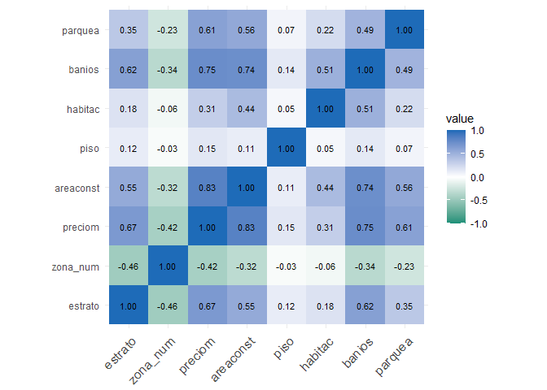

  ```r
  df_apto <- Datos[Datos$tipo == "Apartamento",]

          correlation_matrix <- cor(df_apto[,c("estrato", "zona_num", "preciom", "areaconst", "piso", "habitac", "banios", "parquea")])

          correlation_df <- reshape2::melt(correlation_matrix)

          ggplot(data = correlation_df, aes(x=Var1, y=Var2, fill=value)) +
            geom_tile() +
            geom_text(aes(label=sprintf("%.2f", value)), color="black", size=3) +
            scale_fill_gradient2(low = "#148F77", high = "#1E6BB8", mid = "white",
                                 midpoint = 0, limit = c(-1,1), space = "Lab") +
            theme_minimal() +
            theme(axis.text.x = element_text(angle = 45, vjust = 1,
                                             size = 12, hjust = 1),
                  axis.title = element_blank()) +
            coord_fixed()
  ```

Regresar ...